# DSCI 310: Predicting Wine Cultivars

Author

Zhibek Dzhunusova, Andrea Jackman, Kaylan Wallace & Chuxuan Zhou

## Summary

In this project, we asked whether we can predict what cultivar that a wine was derived from based on its chemical properties.

The data was sourced from the UCI Machine Learning Repository (Aeberhard and Forina 1991). It contains data $178$ wines from Italy derived from three different cultivars. Each row represents the chemical and physical properties of a different wine, such as its concentration of alcohol, magnesium level, and hue.

Using a k-nearest neighbors algorithm we attempted to predict the cultivar of an unknown wine based on physiochemical properties such as alcohol content and magnesium levels. Our model achieved 98% accuracy on our test data, but struggled to accurately predict the origin of wines from cultivar 2. This demonstrates that most cultivars are strongly distinguished by their physiochemical properties with some overlap between similar cultivars. Our analysis effectively identified chemical properties that strongly distinguish cultivars. This provides valueable information for winemakers about which grapes to cultivate to achieve their desired wine characteristics and informs future innovation in the wine industry.

## Introduction

The recorded chemical properties include:

1. Alcohol content
2. Malic acid (gives the wine a fruity flavour)
3. Ash (left over inorganic matter from the wine-making process)
4. Alkalinity of ash (ability to resist acidification)
5. Magnesium, total phenols (contribute to bitter flavour of wine)
6. Flavanoids (antioxidants that contribute to bitter flavour and aroma of wine)
7. Nonflavanoid phenols (weakly acidic)
8. Proanthocyanins (bitter smell)
9. Color intensity
10. Hue
11. The ratio of OD280 to OD315 of diluted wines (protein concentration)
12. Proline (main amino acid in wine, important aspect of the flavour) (Bai, Wang, and Li 2019).

Using this dataset, our predictive question is: “Can the cultivar a wine is derived from be reliably determined through its physiochemical properties?”

Identifying the chemical properties that distinguish cultivars enables farmers to make informed decisions about grape cultivation, aligning grape varieties with desired wine characteristics. By selecting cultivars known for specific flavor profiles or chemical compositions, farmers can tailor vineyard practices to meet market demands effectively. Moreover, this knowledge empowers brewers to experiment with wine compositions, fostering innovation and the creation of novel flavors. Armed with a deep understanding of wine chemistry, brewers can also strategically market their products, ensuring effective communication of the unique qualities and appeal of each wine to consumers.

## Exploratory Data Analysis

Table 1: Summary statistics for the raw data.

```
| cultivar|    alcohol| malicacid|      ash|
|--------:|----------:|---------:|--------:|
| 1.938202| 13.0006180|  2.336348| 2.366517|
| 0.775035|  0.8118265|  1.117146| 0.274344|




| alcalinity_of_ash| magnesium| total_phenols| flavanoids|
|-----------------:|---------:|-------------:|----------:|
|         19.494944|  99.74157|      2.295112|  2.0292697|
|          3.339564|  14.28248|      0.625851|  0.9988587|




| nonflavanoid_phenols| proanthocyanins| color_intensity|       hue|
|--------------------:|---------------:|---------------:|---------:|
|            0.3618539|       1.5908989|        5.058090| 0.9574494|
|            0.1244533|       0.5723589|        2.318286| 0.2285716|




| X0D280_0D315_ratio|  proline|
|------------------:|--------:|
|          2.6116854| 746.8933|
|          0.7099904| 314.9075|
```

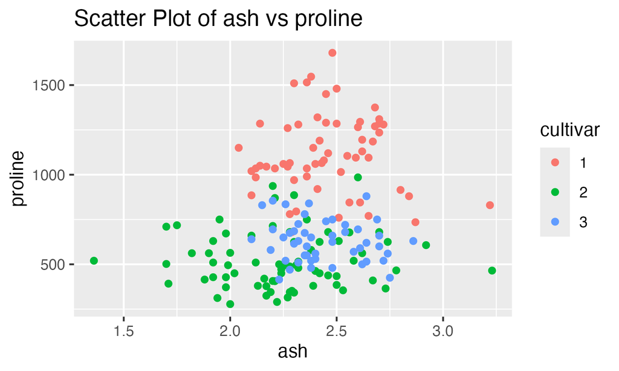

Figure 1: Scatterplot of proline and ash values for each cultivar

Figure 1 depicts the distribution of proline and ash values for each cultivar. Cultivar 1 has more distinct proline and ash values while Cultivar 2 and Cultivar 3 overlap more substantially.

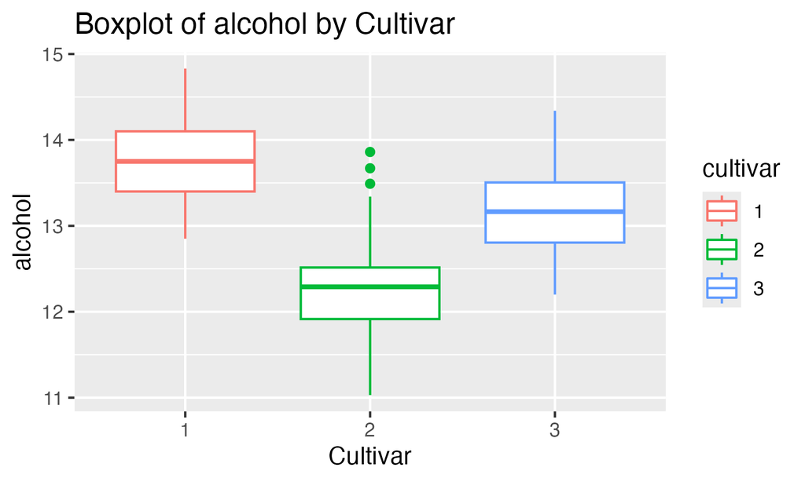

Figure 2: Boxplotplot of alcohol content for each cultivar

Figure 2 shows distribution of alcohol content for the wines from each cultivar. We can see that each cultivar has a narrow range of values that wines tend to fall within which is relatively distinct for each cultivar. This means this could be an effective predictor of cultivar.

## Methods

### Data

This project utilized a K-nearest neighbours classification algorithm to predict what cultivar a wine was derived from based on its various chemical properties. First, we read in data from the UCI Machine Learning Repository. It contains data about various wines from Italy derived from three different cultivars. Each row represents the chemical and physical properties of a different wine, such as its concentration of alcohol, magnesium level and hue.

We then tidied the data and balanced the classes of the classification variable we are interested in. This is because the data set is not extensively large, so ensuring each class has an equal number of observations prevents our model from being biased towards a specific dominant class. Next we calculated some summary statistics to facilitate exploratory data analysis, with the goal of finding key input variables for our model.

## Results & Discussion

Table 2: Model Evaluation metrics.

| Prediction | Truth | n |
| --- | --- | --- |
| 1 | 1 | 15 |
| 2 | 1 | 0 |
| 3 | 1 | 0 |
| 1 | 2 | 1 |
| 2 | 2 | 17 |
| 3 | 2 | 0 |
| 1 | 3 | 0 |
| 2 | 3 | 0 |
| 3 | 3 | 12 |

Our multiclass k-nn model performed relatively well on the test data, achieving an accuracy estimate of approximately $0.98 %$. The confusion matrix reveals insights into the model’s performance across the three cultivar classes. Notably, while the model demonstrated strong precision and recall for predicting cultivar 3, it encountered challenges in accurately classifying cultivar 2. This aligns with our initial hypothesis that certain chemical properties may serve as distinguishing factors for wine cultivars.

However, despite the model’s overall success, its limitations in predicting cultivar 2 suggest avenues for improvement. Future iterations of the model could benefit from refining input variables to better capture the nuances of each cultivar’s chemical composition. Moreover, our findings underscore the importance of further investigation into the unique characteristics of cultivar 3, which consistently stood out in our predictions.

By elucidating the chemical properties that differentiate wine cultivars, our study contributes to the broader goal of simplifying wine classification for consumers. Ultimately, this research not only enhances our understanding of wine chemistry but also has practical implications for wine enthusiasts and industry professionals alike.

## References

Aeberhard, Stefan, and M. Forina. 1991. “Wine.” https://doi.org/10.24432/C5PC7J. https://doi.org/10.24432/C5PC7J.

Bai, X., L. Wang, and H. Li. 2019. “Identification of Red Wine Categories Based on Physicochemical Properties.” In *International Conference on Educational Technology, Management, and Humanities Science*, 1443–48. https://doi.org/10.25236/etmhs.2019.309.

Fehér, J., G. Lengyel, and A. Lugasi. 2007. “The Cultural History of Wine—Theoretical Background to Wine Therapy.” *Central European Journal of Medicine* 2 (4): 379–91. https://doi.org/10.2478/s11536-007-0048-9.

Harutyunyan, M., and M. Malfeito-Ferreira. 2022. “The Rise of Wine Among Ancient Civilizations Across the Mediterranean Basin.” *Heritage* 5 (2): Article 2. https://doi.org/10.3390/heritage5020043.